# 征信系列-用户行为数据分析

凌浩东

11/16/2021

# 1 读入数据

```r
simudata <- read.csv("simudata.csv")
```

# 2 交易笔数和所有用户行为均值箱线图

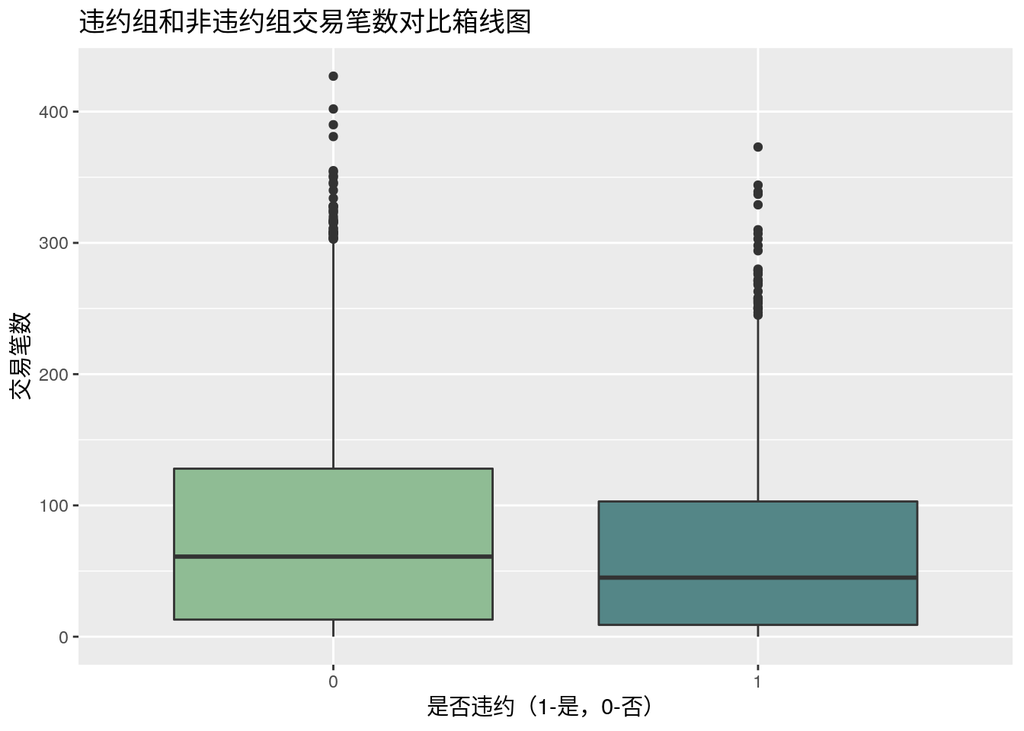

```r
ggplot(simudata, aes(as.factor(black), billnum)) +
  geom_boxplot(fill = c("#8FBC94", "#548687")) +
  labs(x = "是否违约（1-是，0-否）", y = "交易笔数", title = "违约组和非违约组交易笔数对比箱线图")
```

由违约组和非违约组交易笔数对比箱线图可以看出， 非违约组交易笔数的中位数更大， 说明非违约组相对于违约组交易总笔数更多。

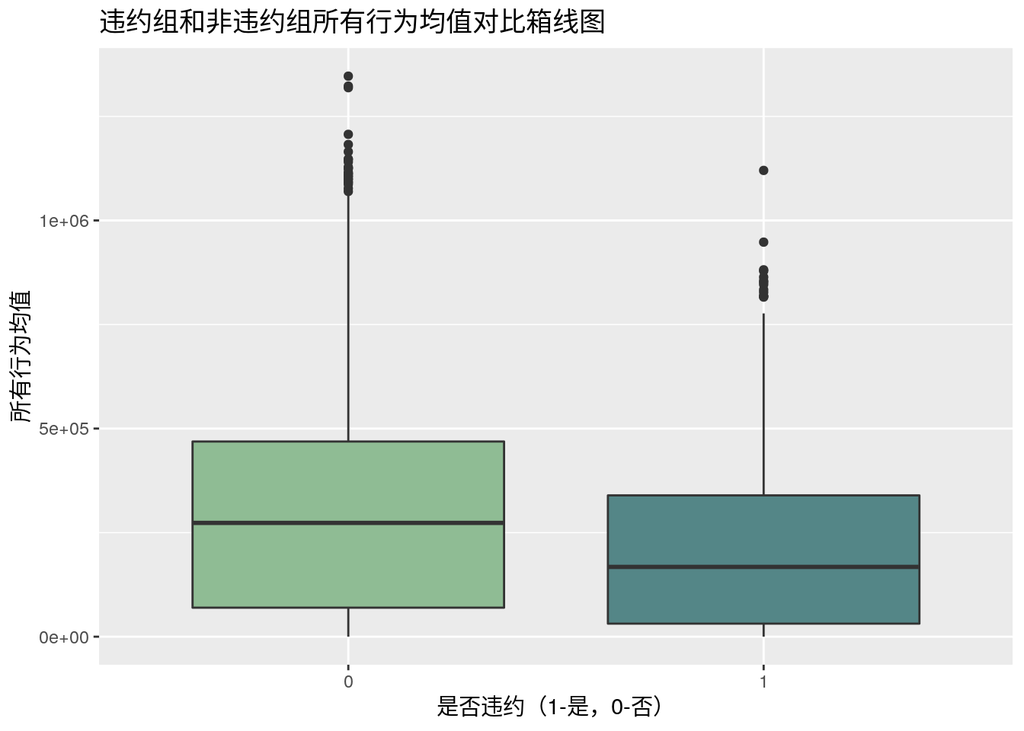

```r
ggplot(simudata, aes(as.factor(black), meanpay)) +
  geom_boxplot(fill = c("#8FBC94", "#548687")) +
  labs(x = "是否违约（1-是，0-否）", y = "所有行为均值", title = "违约组和非违约组所有行为均值对比箱线图")
```

由违约组和非违约组所有行为均值对比箱线图可以看出， 非违约组被记录的所有交易行为的平均金额中位数更大， 说明非违约组的正常交易使用金额偏大。

# 3 用决策树模型进行建模

首先，按照7：3的比例对训练集和测试集进行划分。

```r
set.seed(1234)

simudata$black <- as.factor(simudata$black)

i <- sample(2, nrow(simudata), replace = T, prob = c(0.7, 0.3))
trainset <- simudata[i == 1,]
testset <- simudata[i == 2,]
```

然后，用决策树模型进行建模。

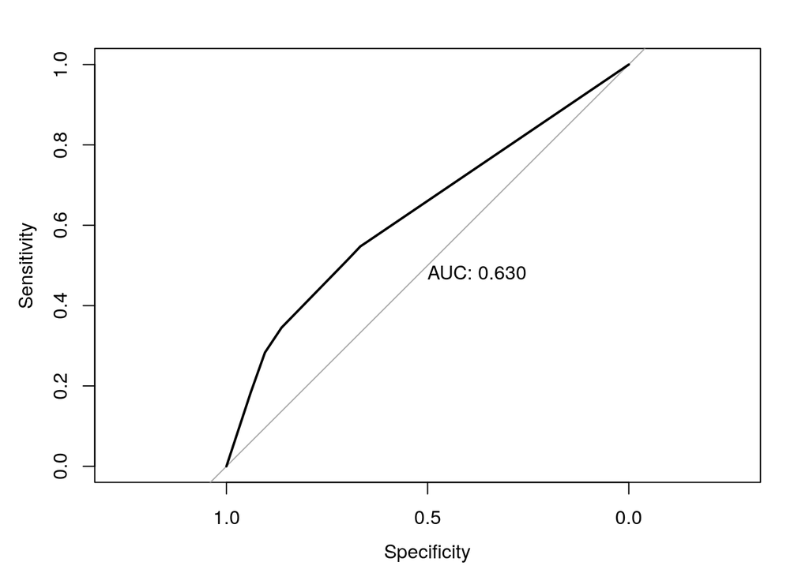

```r
tree <- rpart(black~., data = trainset)
pred <- predict(tree, testset)[,2]
roc(testset$black, pred, plot = T, print.auc = T)
```

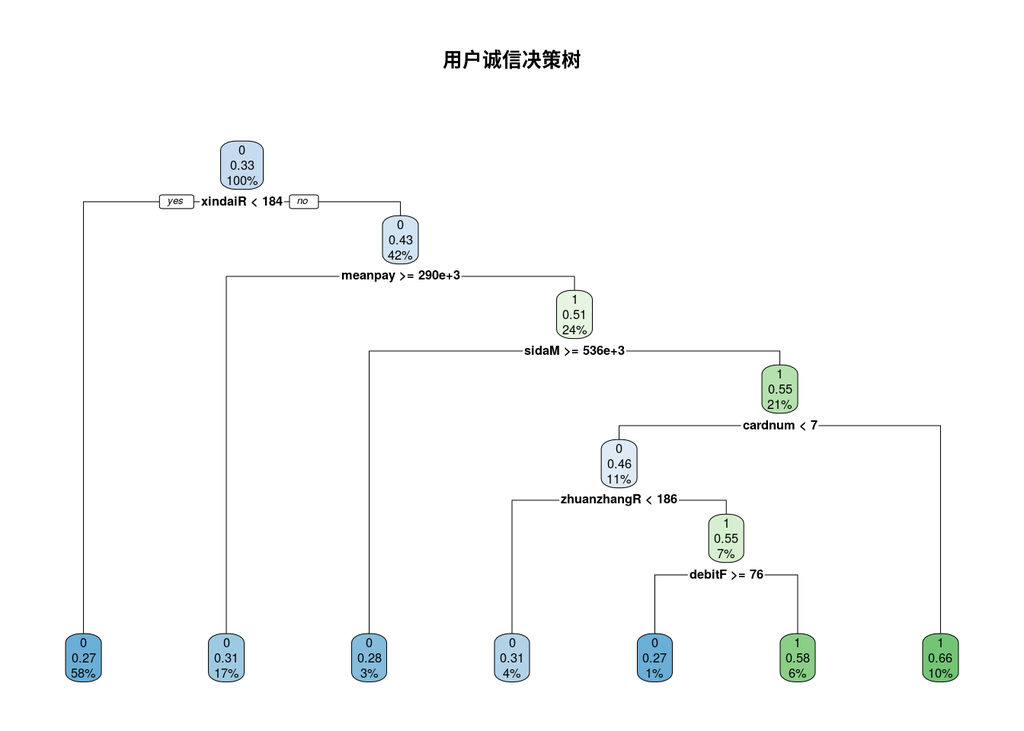

```r
rpart.plot(tree, main = "用户诚信决策树")
```

根据决策树，最近一次信贷消费距今小于184天时， 用户未违约，否则需要查看其所有交易行为的平均金额；

若用户被记录的所有交易行为的平均金额不小于290000时， 用户非违规，否则需要查看四大行消费金额。

若用户在四大行消费金额的平均值不小于536000时， 用户非违规，否则需要查看银行卡数；

若银行卡数不小于7，用户违约，否则需要查看最近一次转账；

若最近一次转账距今小于186天， 用户非违规，否则需要查看借记类消费频率；

若借记类消费频率不小于76， 用户非违规，否则用户违规。